# Assemble POC, environmental and UVP data

Author

Thelma Panaïotis

## Load data

```r
source("utils.R")

load("data/00.carbon_data.Rdata")
load("data/01.all_env.Rdata")
load("data/03.uvp_profiles.Rdata")
rm(coast)
```

## Round coordinates of env and UVP data to match carbon data

- **Case 1: carbon data from Wang**

Carbon data is given on a 2°×2° grid, so we need to round env and UVP coordinates to match the same grid. Carbon longitudes are odd so we need to floor longitude with `precision = 2` and then add 1 to the result. Carbon latitudes are even so we can just round with `precision = 2`.

- **Case 2: carbon data from Argo floats**

```r
# Choose C data source
#c_data <- "wang"
c_data <- "argo"
if (c_data == "wang") {
  df_c <- df_c_mod
} else {
  df_c <- df_c_argo
}
```

### Env data

```r
env <- env %>%
  arrange(lon, lat) %>%
  rowwise() %>%
  mutate(
    lon = ifelse(
      c_data == "wang",
      # for wang, floor longitude and add 1 because carbon longitudes are odd
      roundp(lon, precision = 2, f = floor) + 1,
      # for argo, round to 8°
      roundp(lon, precision = 8, f = round)
    ),
    lat = ifelse(
      c_data == "wang",
      # for wang, round latitude because carbon latitudes are even
      roundp(lat, precision = 2, f = round),
      # for argo, round to 4°
      roundp(lat, precision = 8, f = round)
    )
  ) %>%
  # Average all values on carbon pixels
  group_by(lon, lat) %>%
  summarise_all(mean, na.rm = TRUE) %>%
  ungroup()
```

### UVP data

We can start by plotting a map of UVP profiles.

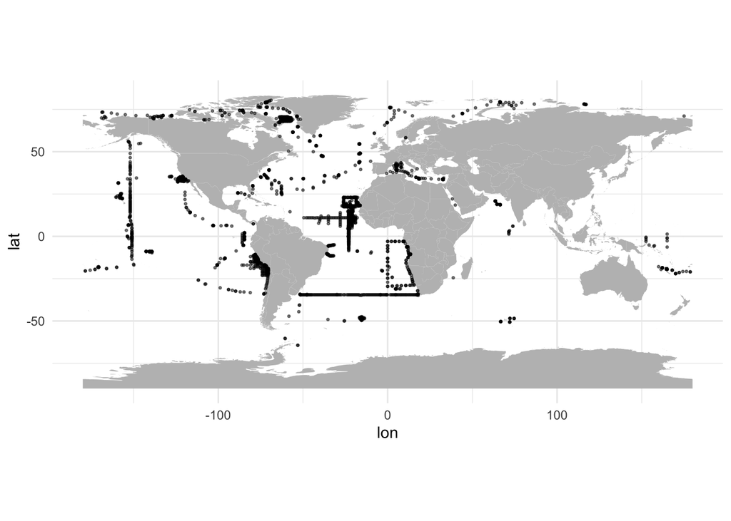

```r
profiles %>%
  ggplot() +
  geom_polygon(data = world, aes(x = lon, y = lat, group = group), fill = "gray") +
  geom_point(aes(x = lon, y = lat), alpha = 0.5, size = 0.5) +
  coord_quickmap()
```

Now let’s round the coordinates and replot the map. We also need to average UVP data on our new grid, but before that let’s also compute the number of UVP profiles per carbon pixel.

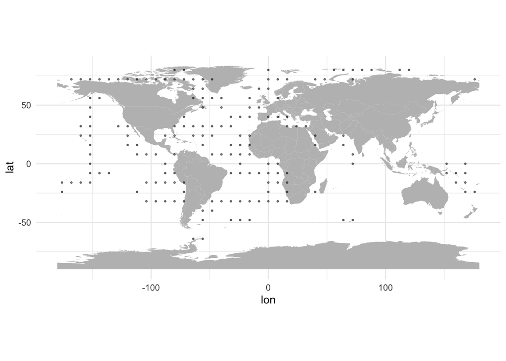

```r
profiles <- profiles %>%
  # Drop profile identification
  select(-profile_id) %>%
  rowwise() %>%
  mutate(
    lon = ifelse(
      c_data == "wang",
      # for wang, floor longitude and add 1 because carbon longitudes are odd
      roundp(lon, precision = 2, f = floor) + 1,
      # for argo, round to 8°
      roundp(lon, precision = 8, f = round)
    ),
    lat = ifelse(
      c_data == "wang",
      # for wang, round latitude because carbon latitudes are even
      roundp(lat, precision = 2, f = round),
      # for argo, round to 4°
      roundp(lat, precision = 8, f = round)
    )
  )

n_profiles <- profiles %>% count(lon, lat)

profiles <- profiles %>%
  # Average all values on carbon pixels
  group_by(lon, lat) %>%
  summarise_all(mean, na.rm = TRUE) %>%
  ungroup()

profiles %>%
  ggplot() +
  geom_polygon(data = world, aes(x = lon, y = lat, group = group), fill = "gray") +
  geom_point(aes(x = lon, y = lat), alpha = 0.5, size = 0.5) +
  coord_quickmap()
```

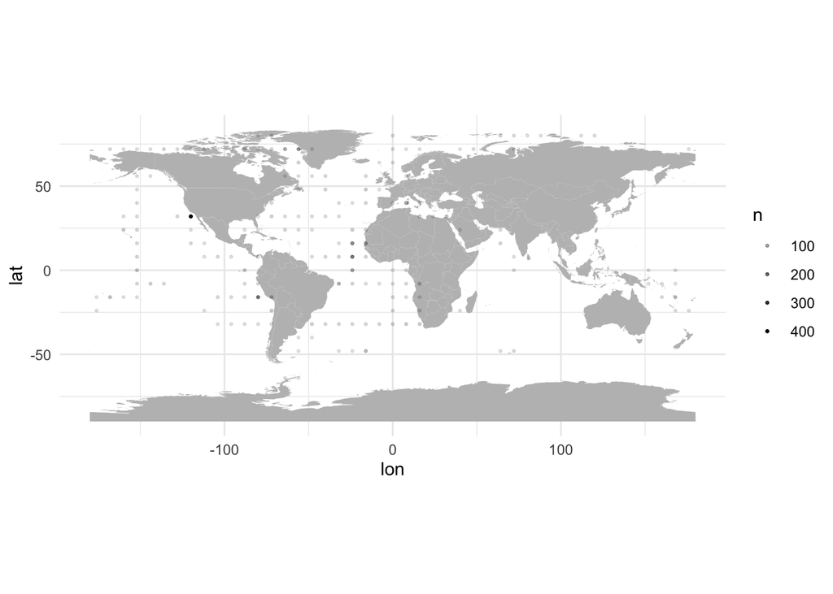

```r
n_profiles %>%
  ggplot() +
  geom_polygon(data = world, aes(x = lon, y = lat, group = group), fill = "gray") +
  geom_point(aes(x = lon, y = lat, alpha = n), size = 0.5) +
  coord_quickmap()
```

We can notice a strong sampling in the California current and in the Peruvian upwelling.

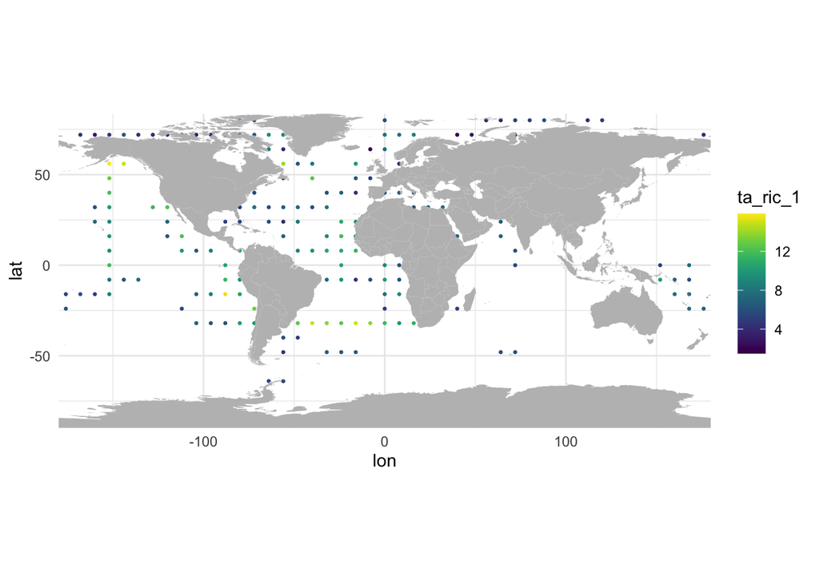

```r
ggmap(profiles, "ta_ric_1", type = "point")
```

## Assemble env, UVP and carbon data

Since all three datasets use the same round coordinates, we can join them together. As a result, we will only get env and carbon data where UVP data is available.

```r
df <- profiles %>%
  left_join(env,  by = join_by(lon, lat)) %>%
  left_join(df_c, by = join_by(lon, lat)) %>%
  select(lon, lat, everything())
```

```r
profiles
```

```
# A tibble: 173 × 37
     lon   lat    datetime abund biovol ta_ric_1 ta_ric_2 ta_ric_3 ta_div_1
   <dbl> <dbl>       <dbl> <dbl>  <dbl>    <dbl>    <dbl>    <dbl>    <dbl>
 1  -176   -24 1425987291.  16.3   77.7     6.33    1.92     1.58     1.56
 2  -176   -16 1426118340.  11     53.6     5.5     1.88     1.66     1.44
 3  -168   -16 1426679721.  16.4  130.      6.38    1.94     1.59     1.54
 4  -168    72 1393899943.  28.1 2899.      4.5     1.05     0.851    1.02
 5  -160   -16 1427770844.  15.5   74.5     5       1.46     1.27     1.00
 6  -160    24 1244340142.  26.6  525.      7.41    1.98     1.47     1.58
 7  -160    32 1317822553.  17.5  156.      6       1.79     1.48     1.44
 8  -160    72 1390236859   20.5  109.      3       0.678    0.680    0.470
 9  -152   -16 1428770042   16.7   53.6     8.67    2.72     2.12     1.93
10  -152    -8 1393993232.  30.8  333.      8.15    2.16     1.55     1.74
# ℹ 163 more rows
# ℹ 28 more variables: ta_eve_1 <dbl>, ta_div_2 <dbl>, ta_div_3 <dbl>,
#   ta_eve_3 <dbl>, ta_mast <dbl>, ss_slope <dbl>, ss_inter <dbl>,
#   mo_size_mean <dbl>, mo_size_sd <dbl>, mo_grey_mean <dbl>, mo_grey_sd <dbl>,
#   mo_elon_mean <dbl>, mo_elon_sd <dbl>, mo_ghet_mean <dbl>, mo_ghet_sd <dbl>,
#   mo_dis <dbl>, mo_mpd <dbl>, mo_nnd <dbl>, mo_eve <dbl>, mo_ric <dbl>,
#   mo_div <dbl>, mo_ori <dbl>, mo_spe <dbl>, mo_ide_mo_dim1 <dbl>, …
```

Our dataset contains 173 points.

Now, we can plot POC data at locations of UVP profiles.

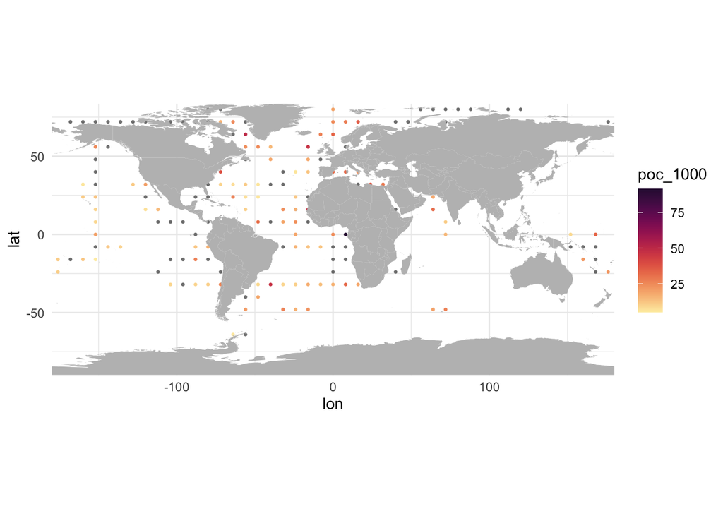

```r
ggmap(df, "poc_1000", type = "point", palette = scale_colour_cmocean(name = "matter"))
```

Or temperature.

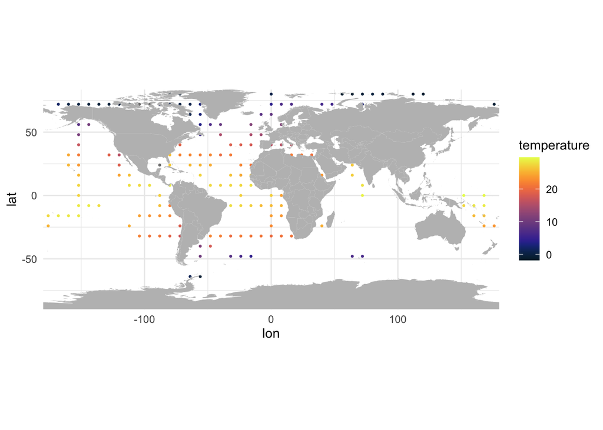

```r
ggmap(df, "temperature", type = "point", palette = scale_colour_cmocean(name = "thermal"))
```

In both cases, we notice that some POC and temperature data is not available at some UVP locations.

```r
summary(df)
```

```
      lon              lat            datetime             abund
 Min.   :-176.0   Min.   :-64.00   Min.   :1.214e+09   Min.   : 11.00
 1st Qu.: -88.0   1st Qu.:-16.00   1st Qu.:1.324e+09   1st Qu.: 20.67
 Median : -40.0   Median : 16.00   Median :1.380e+09   Median : 41.50
 Mean   : -36.3   Mean   : 18.54   Mean   :1.376e+09   Mean   : 70.11
 3rd Qu.:   8.0   3rd Qu.: 56.00   3rd Qu.:1.431e+09   3rd Qu.:103.43
 Max.   : 176.0   Max.   : 80.00   Max.   :1.501e+09   Max.   :560.08

     biovol            ta_ric_1         ta_ric_2         ta_ric_3
 Min.   :   32.21   Min.   : 1.500   Min.   :0.1198   Min.   :0.1955
 1st Qu.:  287.78   1st Qu.: 5.500   1st Qu.:1.3332   1st Qu.:0.8339
 Median :  799.04   Median : 7.000   Median :1.7818   Median :1.2095
 Mean   : 2686.75   Mean   : 7.552   Mean   :1.7262   Mean   :1.1444
 3rd Qu.: 2484.35   3rd Qu.: 9.583   3rd Qu.:2.1596   3rd Qu.:1.4484
 Max.   :36573.00   Max.   :15.857   Max.   :2.9839   Max.   :2.1381

    ta_div_1          ta_eve_1         ta_div_2          ta_div_3
 Min.   :0.03974   Min.   :0.1288   Min.   :0.03211   Min.   :0.1124
 1st Qu.:0.92363   1st Qu.:0.5220   1st Qu.:0.77597   1st Qu.:0.2357
 Median :1.40756   Median :0.6853   Median :1.10490   Median :0.3241
 Mean   :1.26690   Mean   :0.6526   Mean   :1.05672   Mean   :0.4018
 3rd Qu.:1.63523   3rd Qu.:0.8059   3rd Qu.:1.35322   3rd Qu.:0.5532
 Max.   :2.20844   Max.   :0.9426   Max.   :2.02871   Max.   :0.9846

    ta_eve_3         ta_mast           ss_slope         ss_inter
 Min.   :0.1112   Min.   :0.02339   Min.   :-5.093   Min.   :0.8776
 1st Qu.:0.3170   1st Qu.:0.09978   1st Qu.:-2.949   1st Qu.:1.3250
 Median :0.4694   Median :0.18194   Median :-2.645   Median :1.5765
 Mean   :0.5225   Mean   :0.21227   Mean   :-2.676   Mean   :1.5808
 3rd Qu.:0.6553   3rd Qu.:0.32258   3rd Qu.:-2.330   3rd Qu.:1.8055
 Max.   :1.2500   Max.   :0.57143   Max.   :-1.195   Max.   :2.6329

  mo_size_mean        mo_size_sd     mo_grey_mean       mo_grey_sd
 Min.   :-3.80160   Min.   :1.783   Min.   :-4.9494   Min.   :0.5363
 1st Qu.:-0.85106   1st Qu.:3.111   1st Qu.:-0.0367   1st Qu.:1.4938
 Median : 0.06062   Median :3.469   Median : 0.4167   Median :1.7431
 Mean   : 0.17717   Mean   :3.444   Mean   : 0.5802   Mean   :1.7668
 3rd Qu.: 1.30242   3rd Qu.:3.822   3rd Qu.: 1.8492   3rd Qu.:1.9097
 Max.   : 4.56427   Max.   :5.015   Max.   : 3.7787   Max.   :3.3965

```

[output cut: 73 more lines]

```
 Min.   :-1.6364   Min.   :1.794e-05   Min.   :3.156   Min.   :14.40
 1st Qu.:-0.9690   1st Qu.:4.630e-05   1st Qu.:3.614   1st Qu.:23.46
 Median :-0.6091   Median :5.890e-05   Median :4.019   Median :39.66
 Mean   :-0.6158   Mean   :1.201e-04   Mean   :4.112   Mean   :35.62
 3rd Qu.:-0.2747   3rd Qu.:1.182e-04   3rd Qu.:4.588   3rd Qu.:44.99
 Max.   : 0.6803   Max.   :1.655e-03   Max.   :5.298   Max.   :51.81

      att             poc_exp         poc_1000
 Min.   :-1.6034   Min.   : 37.2   Min.   : 4.917
 1st Qu.:-1.0038   1st Qu.:118.6   1st Qu.:11.165
 Median :-0.8586   Median :161.7   Median :17.843
 Mean   :-0.8350   Mean   :189.0   Mean   :19.910
 3rd Qu.:-0.6732   3rd Qu.:243.8   3rd Qu.:25.473
 Max.   :-0.3612   Max.   :495.7   Max.   :91.606
 NA's   :79        NA's   :79      NA's   :80
```

Let’s get rid of these points.

```r
df <- df %>% drop_na()
```

We still have 93 points in our dataset.

Let’s redraw our POC map.

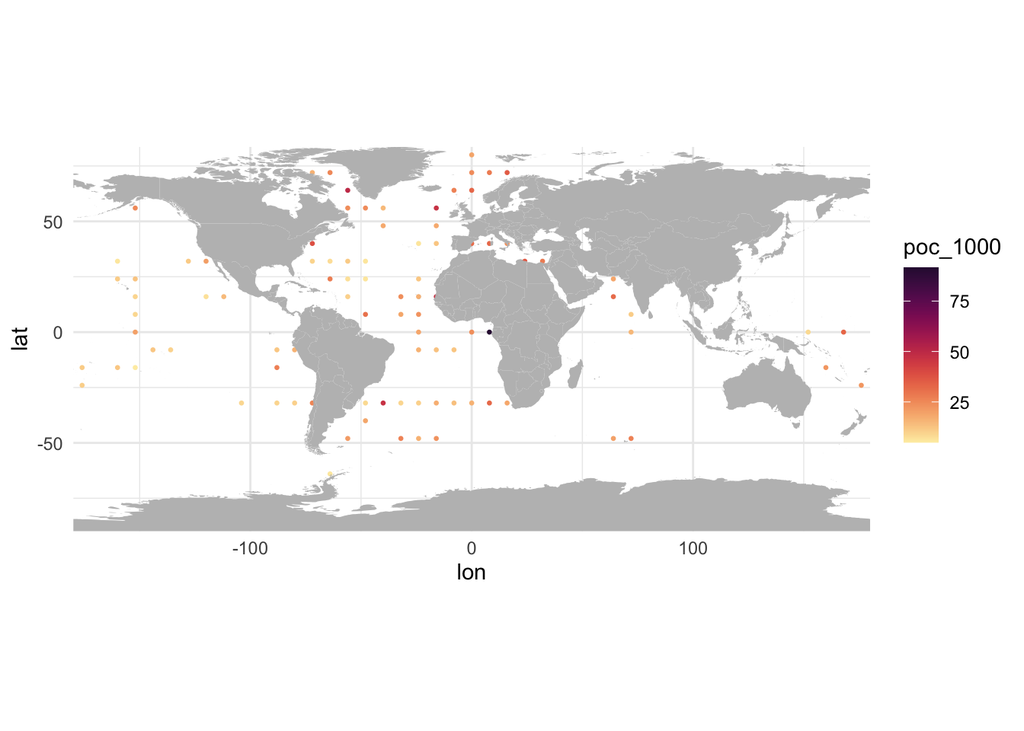

```r
ggmap(df, "poc_1000", type = "point", palette = scale_colour_cmocean(name = "matter"))
```

## Compute Wang attenuation residuals from temp

```r
#ggplot(df) +
#  geom_point(aes(x = temperature, y = log(att)))
```

```r
#df <- df %>% mutate(att_log = log(att))
#att_fit <- lm(att_log ~ temperature, data = df)
#summary(att_fit) # quite good fit
#
#df <- df %>%
#  mutate(
#  pred_att_log = predict(att_fit),
#  #pred_att = exp(pred_log_att),
#  resid_att_log = att_log - pred_att_log
#  )
#
## Plot residuals (log)
#ggplot(df) + geom_point(aes(x = temperature, y = resid_att_log))
#ggmap(
#  df,
#  var = "resid_att_log",
#  type = "point",
#  palette = scale_colour_gradient2(low = "#4575b4", mid = "#ffffbf", high = "#d73027")
#)
```

## Save the resulting dataset

```r
save(df, file = file.path(data_dir, "04.all_data.Rdata"))
```